# Trophic Networks Robustness workflow

Ceres Barros

Gabriel Dansereau

João Braga

August 21 2024

```r
pkgfolder <- "packages/"
dir.create(pkgfolder)

## package installation
.libPaths(pkgfolder)
options(repos = c("predictiveecology.r-universe.dev", getOption("repos")))

if (!"Require" %in% installed.packages()) install.packages("Require", lib = "packages/")

Require::Require(c("cheddar", "colorspace", "data.table", "dplyr", "exactextractr",
    "foreign", "future", "future.apply", "ggExtra", "ggplot2", "ggpubr", "patchwork",
    "reproducible", "raster", "rasterVis", "rredlist", "RSQLite", "sf", "CeresBarros/ToolsCB@master (HEAD)"),
    libPaths = pkgfolder)

## install, but don't load
Require::Require(c("qs", "SpaDES.tools", "terra"), libPaths = pkgfolder, require = FALSE)

options(future.globals.maxSize = 3e+09, reproducible.useNewDigestAlgorithm = 2, reproducible.cachePath = "cache/",
    reproducible.useGDAL = FALSE, reproducible.rasterRead = "raster::raster", nwarnings = 1e+08,
    max.print = 1e+08)
```

All data necessary to run this workflow is available in [Zenodo](https://zenodo.org/doi/10.5281/zenodo.13334864), and automatically accessed by the code.

## Study area

In Dansereau et al. (in prep.) trophic networks were calculated across European countries, Turkey, Georgia and European Russia, under baseline conditions and scenarios of change.

Here, we reduced computational burden by subsetting to a study area polygon drawn with random borders and placed in central Europe. The user is free to change this study area as they see fit.

Note that all lakes are removed.

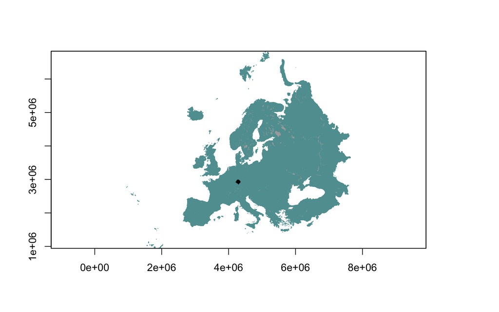

Full study area in blue, with (removed) lakes shown in grey. Subset study area in black.

```r
## 10K grid dbf - pixel IDs
mask10kID <- prepInputs(url = "https://zenodo.org/api/records/13345395/files-archive",
    archive = "13345395.zip", targetFile = "reference_grid_10km.img.vat.dbf", destinationPath = "data/",
    fun = "foreign::read.dbf")

## 10K grid poly
mask10kSHP <- prepInputs(url = "https://zenodo.org/api/records/13345395/files-archive",
    archive = "13345395.zip", targetFile = "grid_10Km.shp", destinationPath = "data/")
mask10kSHP <- as_Spatial(mask10kSHP)

## 10K grid raster in final projection
mask10k <- prepInputs(url = "https://zenodo.org/api/records/13345395/files-archive",
    archive = "13345395.zip", targetFile = "reference_grid_10km.img", destinationPath = "data/",
    fun = "raster::raster")
mask10k[] <- mask10k[]  ## bring raster to memory

## lakes raster
lakes <- prepInputs(url = "https://zenodo.org/api/records/13345395/files-archive",
    archive = "13345395.zip", targetFile = "lakes10k.img", destinationPath = "data/",
    fun = "raster::raster")

plot(mask10k, col = "cadetblue", legend = FALSE)
plot(lakes, add = TRUE, col = "darkgrey", legend = FALSE)

## OPTIONAL
doSubsetting <- TRUE  ## set to FALSE if wanting to run computations for full workflow

if (doSubsetting) {
    ## crop to a smaller study area around the center point of the full study
    ## area.
    pixInEU <- cellFromRowCol(mask10k, nrow(mask10k)/3 * 2, ncol(mask10k)/2)
    pixInEU <- terra::vect(xyFromCell(mask10k, pixInEU), crs = raster::crs(mask10k,
        asText = TRUE))

    ## 100 x 100Km area
    subsetArea <- SpaDES.tools::randomStudyArea(pixInEU, size = 1e+10, seed = 123) |>
        as(Class = "Spatial")

    mask10k <- crop(mask10k, subsetArea) |>
        mask(mask = subsetArea)

    mask10kSHP <- crop(mask10kSHP, subsetArea)

    mask10kID <- mask10kID[mask10kID$Value %in% na.omit(getValues(mask10k)), ]

    lakes <- crop(mask10k, subsetArea) |>
        mask(mask = subsetArea)
}

plot(subsetArea, add = TRUE, col = "black", legend = FALSE, main = "Full (blue) and subset (black) study areas.")
```

## Habitat data preparation

1. Calculate the the area of each GlobCover (v2.2) habitat category (300m2) per pixel – hereafter referred to as a “pixel” – of `mask10k`.
2. Make pixel X habitat matrices used later to filter projected species presences.

```r
source("Dataprep/HABITATdata.R")
```

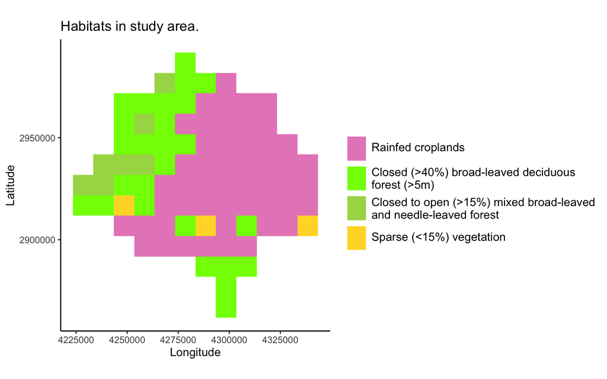

GlobCover land-cover classes with largest areas per 10 Km pixel in study area.

## Species data preparation - IUCN statuses

1. Get the IUCN status of each tetrapod species (`sppIUCNstatus.R`).

```r
source("Dataprep/sppIUCNstatus.R")

objsToRm <- setdiff(ls(all.names = TRUE), c("mask10k", "mask10kID", "mask10kSHP",
    "lakes"))  ## keep these
rm(list = objsToRm)
for (i in 1:3) gc(reset = TRUE)  ## free RAM
```

## Parameter files for batch runs

1. Make `.txt` parameter lists so that networks can be run in batch mode. In interactive mode the script will loop through each line.

```r
source("Dataprep/Make_param_files.R")

objsToRm <- setdiff(ls(all.names = TRUE), c("mask10k", "mask10kID", "mask10kSHP",
    "lakes"))  ## keep these
rm(list = objsToRm)
for (i in 1:3) gc(reset = TRUE)  ## free RAM
```

## Build first baseline networks

1. Obtain pixel X habitat matrix derived from projected land-cover for baseline conditions (`HABITATdata.R`, sourced in `Network_sims.R`). Habitat modelling/projection steps are not part of this workflow they present a significant portion of the computational time needed (see footnote for details[^1]).
2. Obtain pixel X species matrices derived from projected species distributions (`SPPdata.R`, sourced in `Network_sims.R`). Species distribution modelling/projection steps are not part of this workflow as they present a significant portion of the computational time needed (see footnote for details[^2]).
3. Downscale the metaweb - i.e. combine presence/absence + habitat + trophic information to build a network in each pixel of `mask10k`. Species are consired present in the network as long as they have at least one prey item. For each “local” network, a suite of network metrics are calculated. Output files are:
   - `metrics10kWdietFUND*.rds`, which contains a large table of network metrics (columns) per pixel (lines). Pixel ID’s are under the `PAGENAME` column.
   - `spp10kWdietFUND*`, which contains a large list of adjacency matrices for each pixel. List `names()` refer to the pixel ID (column `PAGENAME` in the `metrics` table).
   - These networks are used to calculate the distribution of no. prey per species across the full study area.

```r
## GET PARAMETERS -------------------------------------- Baseline networks
parameters <- read.table("Param_files/workflowDemo/params_BL.txt", sep = ";")$V1

## change these manually:
useBLextthresh <- FALSE  ## use/calculate BL webs with extinction thresholds
k <- 0  ## define habitat threshold to consider a spp present(% higher than K, so e.g. k = 0 higher than 0)
opt <- FALSE  ## define if using only optimal habitats (=TRUE), or optimal and secondary (=FALSE)
do.pix <- "missing"  ## 'missing' or 'all'
noCPUs <- 1
parallel <- FALSE

source("NetworkProjections/Network_sims.R")

objsToRm <- setdiff(ls(all.names = TRUE), c("mask10k", "mask10kID", "mask10kSHP",
    "lakes"))  ## keep these
rm(list = objsToRm)
for (i in 1:3) gc(reset = TRUE)  ## free RAM
```

## Calculate species extinction thresholds

1. Use the networks above to calculate the distribution of no. prey each species has across all networks of the study area. Then, for each species, calculate extinction thresholds based on quantile values of no. of prey.
2. Quantiles values calculated: 10%, 25%, 75% and 90%. Minimum and median prey values are also calculated

```r
## setting directories
results.dir <- "NetworkSims/Baseline_SDMpres_GlobCover/No_ext_thresh/"
noCPUs <- 1
source("Dataprep/Ext_thresh_minquantmedian_noprey.R")

objsToRm <- setdiff(ls(all.names = TRUE), c("mask10k", "mask10kID", "mask10kSHP",
    "lakes"))  ## keep these
rm(list = objsToRm)
for (i in 1:3) gc(reset = TRUE)  ## free RAM
```

## Re-build baseline networks using species extinction thresholds

1. Re-builds all networks, but this time filter species presences according to a minimum no. of prey defined by one of the quantile values calculated above (i.e. the ‘extinction thresholds’).

```r
## Baseline networks
parameters <- read.table("Param_files/workflowDemo/params_BL.txt", sep = ";")$V1
## subset to one stat model
parameters <- grep("current_wm_bin_RF", parameters, value = TRUE)
## change these manually:
useBLextthresh = TRUE  ## use/calculate BL webs with extinction thresholds
k = 0  ## define habitat threshold to consider a spp present(% higher than K, so e.g. k = 0 higher than 0)
opt <- FALSE  ## define if using only optimal habitats (=TRUE), or optimal and secondary (=FALSE)
quants <- c("min", "median", "quant10", "quant25", "quant50", "quant75", "quant90")  ## choose quantiles or 'all'
do.pix <- "missing"  ## 'missing' or 'all'
noCPUs <- 1
parallel <- FALSE

source("NetworkProjections/Network_sims.R")

objsToRm <- setdiff(ls(all.names = TRUE), c("mask10k", "mask10kID", "mask10kSHP",
    "lakes"))  ## keep these
rm(list = objsToRm)
for (i in 1:3) gc(reset = TRUE)  ## free RAM
```

## Sensitivity analyses

1. Run a sensitivity analyses of baseline network metrics to extinction thresholds.
2. This analysis will determine the extinction threshold is picked for further network projections.

```r
## Set working directories --------------------------
res.dir <- "NetworkSims/Baseline_SDMpres_GlobCover/"
out.dir <- "NetworkSims/Baseline_SDMpres_GlobCover/Analyses/SensAnalysis"
dir.create(out.dir, recursive = TRUE)

source("Analyses/1_SensAnalysis_BL.R")

objsToRm <- setdiff(ls(all.names = TRUE), c("mask10k", "mask10kID", "mask10kSHP",
    "lakes"))  ## keep these
rm(list = objsToRm)
for (i in 1:3) gc(reset = TRUE)  ## free RAM
```

## Project networks under scenarios of change

1. Builds/projects networks according to a scenario of change.
2. Here, two extreme scenarios are considered to explore the lower boundaries of network robustness to projected changes:
- Climate change - A climate change scenario using the HadGEM2-AO global circulation model and the RCP 8.5 emissions scenario (equivalent to CMIP6 SSP5-8.5), which affected species distributions (see above for details). Habitat (i.e. land cover) composition was assumed to remain the same.
- IUCN extinctions - A targeted extinctions scenario, where we assumed a failure to project all species listed as Critically Endangered, Endangered and Vulnerable in the IUCN Red List. These species were removed from their entire range. Both habitat and climate are assumed to remain the same, meaning that the ranges of all other species are unchanged.
3. For projections across all pan-European countries, we picked a quantile value of 10% was picked as the extinction threshold (see Supplemental Information). For simplicity, we chose to keep it for this demonstration workflow.

```r
## CC/extinction scenarios
parameters <- read.table("Param_files/workflowDemo/params_Scen_FULL.txt", sep = ";")$V1
## subset to one GCM and stat model
parameters <- grep("hd_rcp85_wm_bin_RF|current_wm_bin_RF", parameters, value = TRUE)
## change these manually:
useBLextthresh = TRUE  ## use/calculate BL webs with extinction thresholds
k = 0  ## define habitat threshold to consider a spp present(% higher than K, so e.g. k = 0 higher than 0)
opt <- FALSE
quants <- "quant10"
do.pix <- "missing"  ## 'missing' or 'all'
noCPUs <- 1
parallel <- FALSE

source("NetworkProjections/Network_sims.R")

objsToRm <- setdiff(ls(all.names = TRUE), c("mask10k", "mask10kID", "mask10kSHP",
    "lakes"))  ## keep these
rm(list = objsToRm)
for (i in 1:3) gc(reset = TRUE)  ## free RAM
```

## Analyses of results and visual outputs

### Robustness and trophic level

1. Make/load the `masterdietFUND*` files to get the `master*` tables – these are tables containing pixel X species presence/absence information according to projected network composition.
2. Calculate the initial trophic level (in baseline networks generated under the same extinction threshold) occupied by species that went primarily extinct and secondarily extinct in each scenario.
- Primary extinctions = extinctions due to loss of climate suitability or because species removed from its entire range under the IUCN extinctions scenario.
- Secondary extinctions = extinctions due to loss of prey only. These species could otherwise be present, according to their climate and habitat niche.

```r
## Set working directories --------------------------
bl.dir <- "NetworkSims/Baseline_SDMpres_GlobCover"
res.dir <- scen.dir <- "NetworkSims/IUCN_CC_sims_GlobCover"
out.dir <- "NetworkSims/IUCN_CC_sims_GlobCover/Analyses"

fig.dir <- file.path(out.dir, "Figs")
dir.create(fig.dir, recursive = TRUE)

## chose extinction threshold to analyse
quant <- "quant10"

## get some more functions
source("Tools/Rob&TL_functions.R")
source("Tools/compilePextSext.R")
source("Tools/summStatsByPixSpp.R")
source("Tools/plotFuns.R")

## get master files (make if need be) skips doing master files if they have
## been produced before set to TRUE if something went wrong and they need to be
## recalculated
redo <- FALSE
save <- TRUE  ## save tables to disk?
returnMaster <- FALSE  ## return the tables (TRUE), or just save them to disk
source("Dataprep/make_Master_Files.R")

## compile all metrics but don't return
doCache <- if (redo) "overwrite" else TRUE
invisible(reproducible::Cache(loadResultsMetrics, bl.dir = bl.dir, res.dir = res.dir,
    out.dir = out.dir, quant = quant, useCache = doCache, userTags = "loadAllmetrics"))

source("Analyses/2_Rob&TL.R")

objsToRm <- setdiff(ls(all.names = TRUE), c("mask10k", "mask10kID", "mask10kSHP",
    "lakes"))  ## keep these
rm(list = objsToRm)
for (i in 1:3) gc(reset = TRUE)  ## free RAM
```

### Maps

```r
## Set working directories --------------------------
bl.dir <- "NetworkSims/Baseline_SDMpres_GlobCover"
res.dir <- "NetworkSims/IUCN_CC_sims_GlobCover"
out.dir <- "NetworkSims/IUCN_CC_sims_GlobCover/Analyses"
fig.dir <- file.path(out.dir, "Figs")

dir.create(fig.dir, recursive = TRUE)

## chose extinction threshold to analyse
quant <- "quant10"

## LOADING RESULTS ----------------------------------
redo <- FALSE  ## redo the compilation of network metrics and purge cache?
source("Dataprep/CompileRes_allMetrics.R")

source("Analyses/3_Maps.R")

objsToRm <- setdiff(ls(all.names = TRUE), c("mask10k", "mask10kID", "mask10kSHP",
    "lakes"))  ## keep these
rm(list = objsToRm)
for (i in 1:3) gc(reset = TRUE)  ## free RAM
```

## Publication figures

```r
fig.dir <- "NetworkSims/IUCN_CC_sims_GlobCover/Analyses/Figs/pubFigs/"
source("Analyses/4_pubFigures.R")
```

```r
## change to results 'hold'/'show' once paper is out.
knitr::include_graphics(file.path(fig.dir, "robMap_boxplotsTLXRobPoints_v.png"))
```

## References

Dansereau, Gabriel, João Braga, Francesco Ficetola, Núria Galiana, Dominique Gravel, Luigi Maiorano, José M. Montoya, et al. in prep. “Overcoming the Disconnect Between Network Science and Ecosystem Management and Conservation.”

Maiorano, Luigi, Giovanni Amori, Massimo Capula, Alessandra Falcucci, Monica Masi, Alessandro Montemaggiori, Julien Pottier, et al. 2013. “Threats from Climate Change to Terrestrial Vertebrate Hotspots in Europe.” Edited by Daniele Canestrelli. *PLoS ONE* 8 (9): e74989. https://doi.org/10.1371/journal.pone.0074989.

[^1]: Habitat layer is the GlobCover v2.2 land-cover used in Maiorano et al. (2013).
[^2]: Species distributions were projected under baseline climate conditions (climate normals for 1960-1990) and future climate conditions for 2050 (average for 2041-2060). Future climate conditions were derived from IPCC CMIP5 ensemble projections using the HadGEM2-AO global circulation model and the RCP 8.5 emissions scenario (equivalent to CMIP6 SSP5-8.5 – see above). Species were allowed to follow their climate niche without restrictions.